# STAT/MATH 495: Problem Set 03

Harrison Marick

2017-09-26

The function below takes two data sets of equal length and computes the root mean squared error. I use this function in the following problems.

```r
rmse <- function(actual, predicted)
{
    error=actual-predicted
    sqrt(mean(error^2))
}
```

# Question

For both `data1` and `data2` tibbles (a tibble is a data frame with some [metadata](https://blog.rstudio.com/2016/03/24/tibble-1-0-0#tibbles-vs-data-frames) attached):

- Find the splines model with the best out-of-sample predictive ability.
- Create a visualizaztion arguing why you chose this particular model.
- Create a visualizaztion of this model plotted over the given $(x_i, y_i)$ points for $i=1,\ldots,n=3000$.
- Give your estimate $\widehat{\sigma}$ of $\sigma$ where the noise component $\epsilon_i$ is distributed with mean 0 and standard deviation $\sigma$.

# Data 1

Below, I have randomly split Data 1 into two sets: A and B. I then create a splines model with set A as my learning set and test on B. I compute the RMSE and then do the opposite: model with B and test on A. The average is my score, but of course I did not specify the degrees of freedom of the models. In order to optimize my selection for degrees of freedom, I repeated the cross validation process 100 times, where df=1,…,100. The optimal degrees of freedom is the number that yields the best score, or smallest RMSE. In this case, 30 yielded the lowest RSME.

```r
set.seed(27)
sample_a<-filter(data1, ID %in% sample(data1$ID, length(data1$ID)/2)) #samples half of the data
sample_b<-filter(data1, !(ID %in% sample_a$ID)) #other half of data

score_data=data.frame(df=rep(0, 100), score=rep(0,100)) #initialize data structure to store DF and score for each model.
for (i in 1:100){
learn_A<-smooth.spline(sample_a$x, sample_a$y, df=i) #learning on a, with df=i
pred=predict(learn_A, sample_b$x) #predict on b
sample_b$y_pred<-pred[2]$y #create predicted column

learn_B<-smooth.spline(sample_b$x, sample_b$y, df=i) #learn on B
pred=predict(learn_B, sample_a$x) #predict on A
sample_a$y_pred<-pred[2]$y#create predicted column
a_score=rmse(sample_a$y, sample_a$y_pred) #score when pred on A
b_score=rmse(sample_b$y, sample_b$y_pred) #score when pred on B
score=(a_score+b_score)/2 #average
score_data$df[i]=i
score_data$score[i]=score

}

with(score_data, df[score == min(score)]) #find minimum
```

```
## [1] 30
```

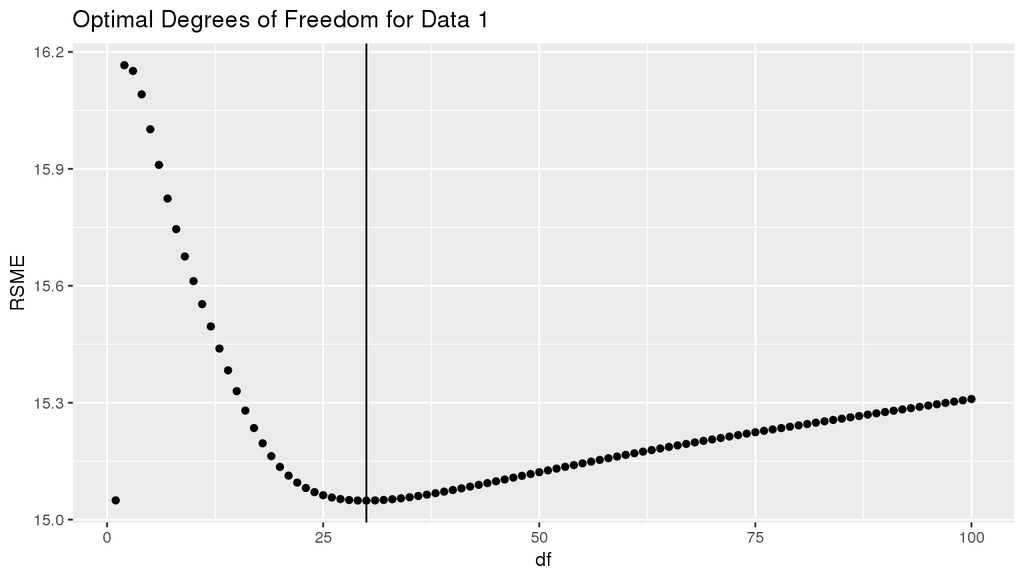

```r
ggplot(score_data, aes(df, score)) + geom_point() + ggtitle("Optimal Degrees of Freedom for Data 1")+geom_vline(xintercept=30) + ylab("RSME") #plot for justification
```

The above graph is a scatterplot of degrees of freedom versus the cross validation score (average RSME). I have placed a vertical line on the above graph where $df=30$ to make it clear that the minimum occurs at $df=30$.

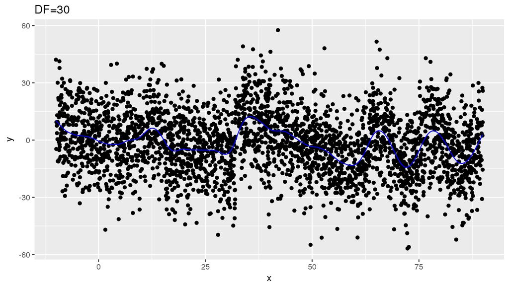

```r
mod1 <- smooth.spline(x=data1$x, y=data1$y, df=30) #creates optimal model
mod1_tidy <- mod1 %>%
  broom::augment()
plot1 <- ggplot(mod1_tidy, aes(x=x)) +
  geom_point(aes(y=y)) +
  geom_line(aes(y=.fitted), col="blue") + #places fitted line over scatterplot
  ggtitle("DF=30") #overlays model with scatterplot
plot1
```

Above is a graph of the fitted model overlaying the original dataset. Clearly, there is a significant amount of the noise in the dataset, as there is significant scatter from the line.

```r
sd(residuals(mod1), na.rm=TRUE)
```

```
## [1] 14.90193
```

We can estimate the noise in the model by the residuals from the model. Naturally, the best way to estimate $\sigma$, the standard deviation of the noise component, is with the standard deviation of the residuals. This leaves us with $\widehat{\sigma}=14.90$.

# Data 2

```r
#NO COMMENTS IN THIS CHUNK, SINCE IT IS IDENTICAL TO ABOVE
set.seed(58)
sample_a2<-filter(data2, ID %in% sample(data2$ID, length(data2$ID)/2))
sample_b2<-filter(data2, !(ID %in% sample_a2$ID))

score_data2=data.frame(df=rep(0, 100), score=rep(0,100))
for (i in 1:100){
learn_A2<-smooth.spline(sample_a2$x, sample_a2$y, df=i)
pred=predict(learn_A2, sample_b2$x)
sample_b2$y_pred<-pred[2]$y

learn_B2<-smooth.spline(sample_b2$x, sample_b2$y, df=i)
pred=predict(learn_B2, sample_a2$x)
sample_a2$y_pred<-pred[2]$y
a_score2=rmse(sample_a2$y, sample_a2$y_pred)
b_score2=rmse(sample_b2$y, sample_b2$y_pred)
score=(a_score2+b_score2)/2
score_data2$df[i]=i
score_data2$score[i]=score

}

with(score_data2, df[score == min(score)])
```

```
## [1] 28
```

I conducted the same process above that I did with Data 1. Here, the optimal degrees of freedom for our splines model is 28. We can see in the graph below that the minimum estimated RSME through cross validation is lowest when df=28.

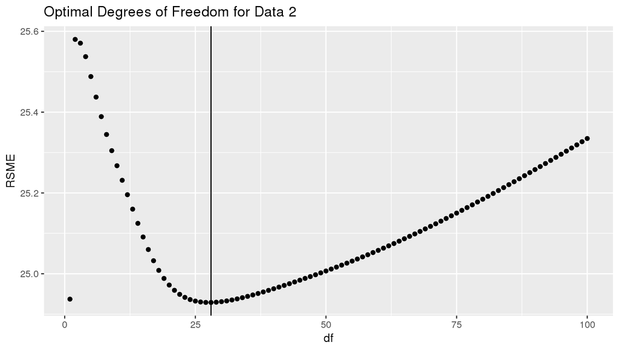

```r
ggplot(score_data2, aes(df, score)) + geom_point() + ggtitle("Optimal Degrees of Freedom for Data 2")+geom_vline(xintercept=28) + ylab("RSME") #plot of DF vs RSME for justification
```

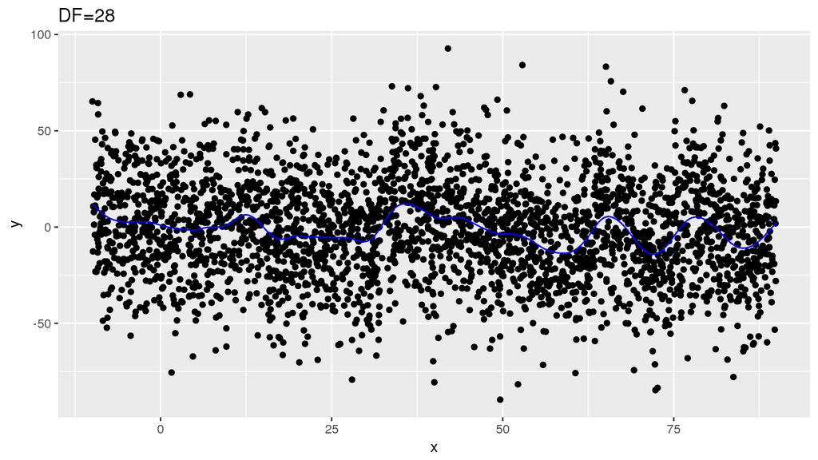

```r
#CODE IS SAME AS ABOVE
mod2 <- smooth.spline(x=data2$x, y=data2$y, df=28)
mod2_tidy <- mod2 %>%
  broom::augment()
plot2 <- ggplot(mod2_tidy, aes(x=x)) +
  geom_point(aes(y=y)) +
  geom_line(aes(y=.fitted), col="blue") + #places fitted line over scatterplot
  ggtitle("DF=28")
plot2
```

The plot above overlays the fitted splines model with 28 degrees of freedom with the data. Again, there is plenty of noise in the dataset, which is evident in that the points do not follow our modeled curve very closely.

```r
sd(residuals(mod2), na.rm=TRUE)
```

```
## [1] 24.71788
```

I have estimated $\sigma$, the standard deviation of the noise component of the model, just as I did with the first dataset. Here, we have $\widehat{\sigma}$=24.71